# Reproducible Research: Peer Assessment 1

Loading the neccessary libraries

```r
require(reshape2)
require(lattice)
```

## Loading and preprocessing the data

### Loading the data

This analysis presumes that source data are lockated on the same working directory with this script.

```r
raw_data<-read.csv("activity.csv")
```

### Processing/Transforming the data

Aggregate the number of steps per day ignoring missing values. This data set will be needed to answer the first question below (What is the mean total number of steps taken per day?)

```r
agg_steps_per_date<-aggregate(steps ~ date,data=raw_data,sum)
```

Aggregate (average) the number of steps per interval across all days - ignoring missing values. This data set will be needed to answer the first question below (What is the average daily activity pattern?)

```r
agg_steps_per_interval<-aggregate(steps ~ interval,data=raw_data, mean)
```

## What is mean total number of steps taken per day?

For this part of the assignment, you can ignore the missing values in the dataset.

1. Make a histogram of the total number of steps taken each day

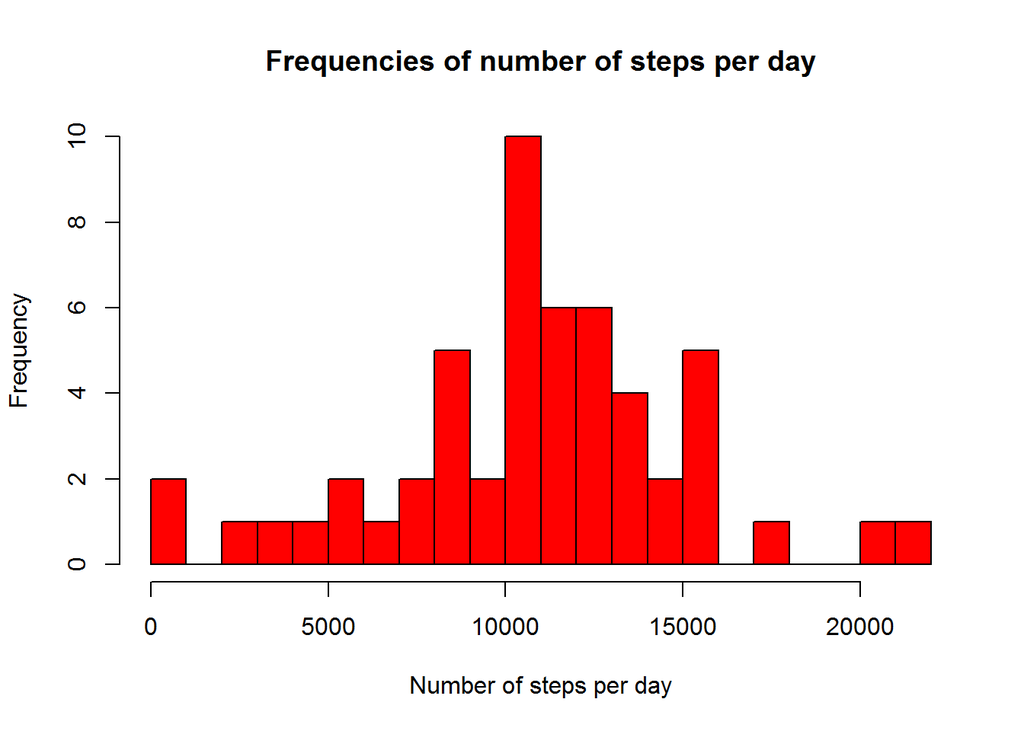

```r
hist(agg_steps_per_date$steps,breaks=20,col="red",xlab="Number of steps per day",main="Frequencies of number of steps per day")
```

2. Calculate and report the mean and median total number of steps taken per day

```r
mean(agg_steps_per_date$steps)
```

```
## [1] 10766
```

```r
median(agg_steps_per_date$steps)
```

```
## [1] 10765
```

## What is the average daily activity pattern?

1. Make a time series plot (i.e. type = “l”) of the 5-minute interval (x-axis) and the average number of steps taken, averaged across all days (y-axis)

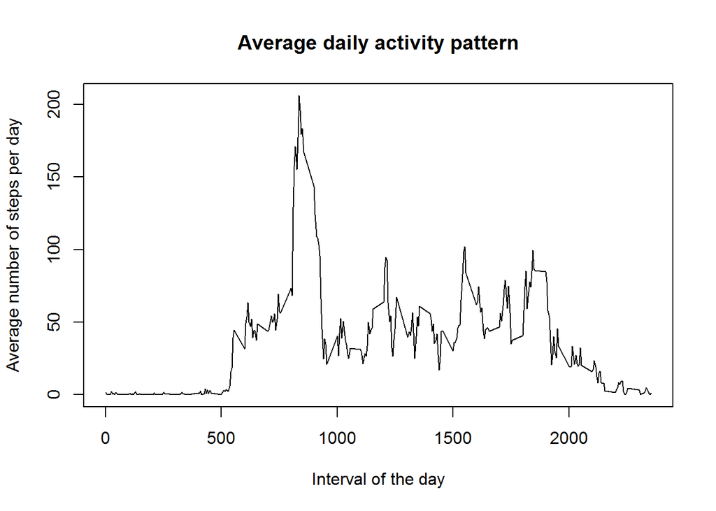

```r
plot(agg_steps_per_interval$interval,agg_steps_per_interval$steps,type="l",xlab="Interval of the day",ylab="Average number of steps per day",main="Average daily activity pattern")
```

```r
agg_steps_per_interval[which.max(agg_steps_per_interval[,2]),]
```

```
##     interval steps
## 104      835 206.2
```

## Imputing missing values

Note that there are a number of days/intervals where there are missing values (coded as NA). The presence of missing days may introduce bias into some calculations or summaries of the data.

1. Calculate and report the total number of missing values in the dataset (i.e. the total number of rows with NAs)

```r
sum(is.na(raw_data$steps))
```

```
## [1] 2304
```

2. Filling in all of the missing values in the dataset. Add the column with mean number of steps per interval to the initial data set.

```r
complete_data<-merge(raw_data,agg_steps_per_interval,by.x="interval",by.y="interval")
```

introduce new column with complete values. First add the initial step data

```r
complete_data$complete_steps<-complete_data$steps.x
```

Now let’s add the averaged value of steps for missing values

```r
complete_data[is.na(complete_data$steps.x),]$complete_steps<-complete_data[is.na(complete_data$steps.x),]$steps.y
```

3. Create a new dataset that is equal to the original dataset but with the missing data filled in. Finally lets keep only the columns we want in complete dataset

```r
tidy_data<-subset(complete_data,select=c(interval,date,complete_steps))
```

Name the columns approprietly

```r
names(tidy_data)=c("interval","date","steps")
```

4. Make a histogram of the total number of steps taken each day and Calculate and report the mean and median total number of steps taken per day. Do these values differ from the estimates from the first part of the assignment? What is the impact of imputing missing data on the estimates of the total daily number of steps?

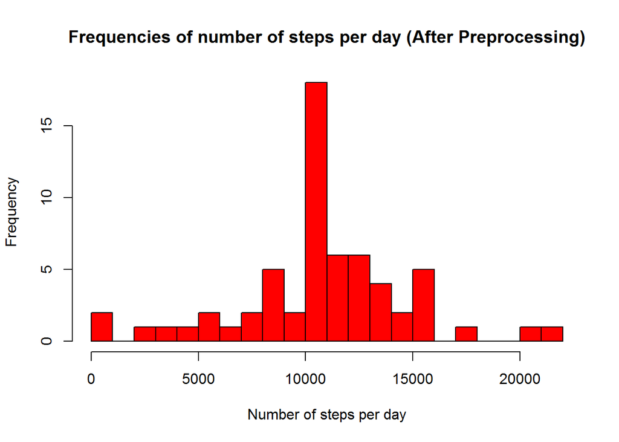

```r
hist(aggregate(steps ~ date,data=tidy_data,sum)$steps,breaks=20,col="red",xlab="Number of steps per day",main="Frequencies of number of steps per day (After Preprocessing)")
```